# Analysis of Serial Measures

Holger Burchert

16 5 2021

This code is an implementation of the article “Analysis of Serial Measures in Medical Research” by Matthews et al. 1990:

Matthews, J., Altman, D. G., Campbell, M. J., & Royston, P. (1990). Analysis of serial measurements in medical research. British Medical Journal, 300(6719), 230-235.

For each participant of two groups (Group A and Group B) a linear regression will be performed to summarise the data. A student’s t-test is then performed to see wheather the groups differ.

```r
data <- read.csv(
    "C:/Users/neo/Documents/Privat/R/Summary Code/summary2.csv",
    header = TRUE,
       sep = ";"
  )
```

First some storages are built which will later be filled with outcomes from the regressions.

```r
# Group A suffix = .A
 models.A   <- list() # storage for regression models
 slopes.A   <- c()    # stroage for the slopes
r.sqrds.A   <- c()    # storage for r squareds
```

Now, a loop will be created. It conducts a regression von HR vs time and repeats this for each participant. During this loop, each regression model is stored in “models.A”, while each slope is stored in “slopes.A” and the r-squared is stored in “r.sqrds.A”.

```r
# Looping regressions of HR vs time for Group A
for (i in names(data)[-1][1:9]) { # [-1] = omits time, [1:9] = desired columns
   models.A[[i]] <-         lm(get(i) ~ time, data)                 # store model
   slopes.A[[i]] <-    coef(lm(get(i) ~ time, data))["time"]        # store slope
  r.sqrds.A[[i]] <- summary(lm(get(i) ~ time, data))[["r.squared"]] # store r^2
}
```

Since having the r-squareds is not enough (Anscombe’s Quartett) all the regressions for each participant are plotted to evaluate whether the linear model is a good fit to the data. This is, again, done by looping the regressions.

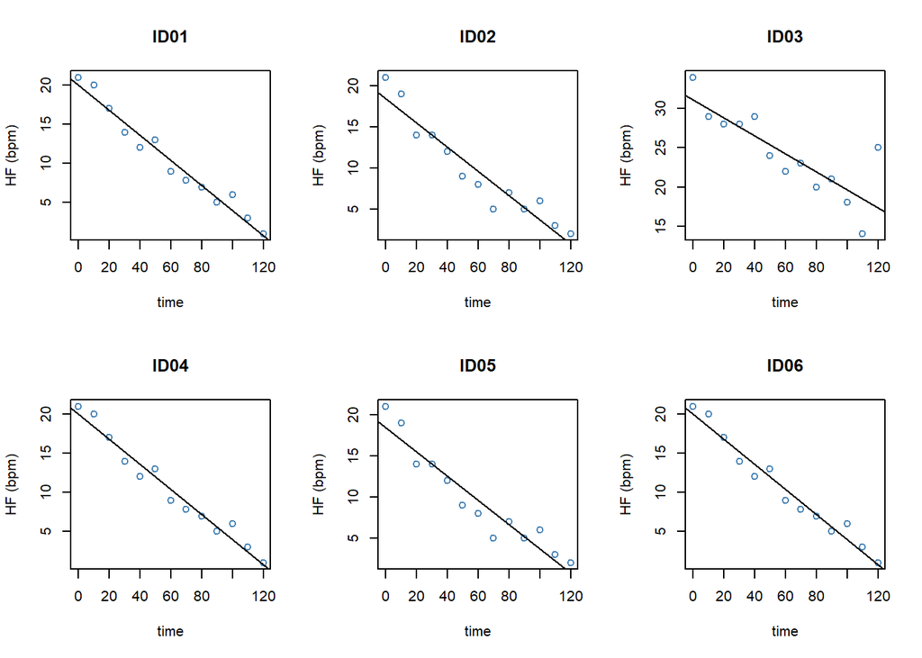

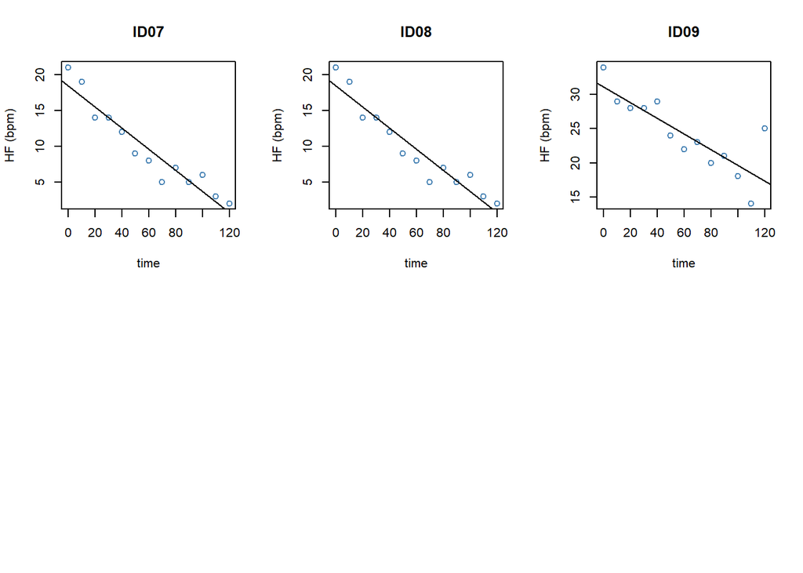

```r
par(mfrow = c(2, 3)) # merges the graphs to be looped in one graph

for (i in names(data)[-1][1:9]) { # [-1] = omits time, [1:9] = Group A
  plot(get(i) ~ time,
         ylab = "HF (bpm)",
         main = i,
          col = "steelblue",
          data)
  abline(models.A[[i]])  # add linear fit from models
}
```

Finally, the assumptions for linear regression will be checked by inspecting the residual plots for each individual linear regression.

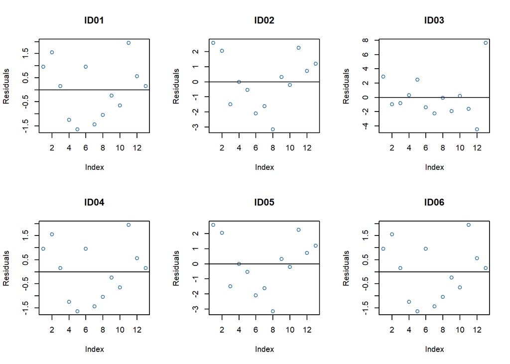

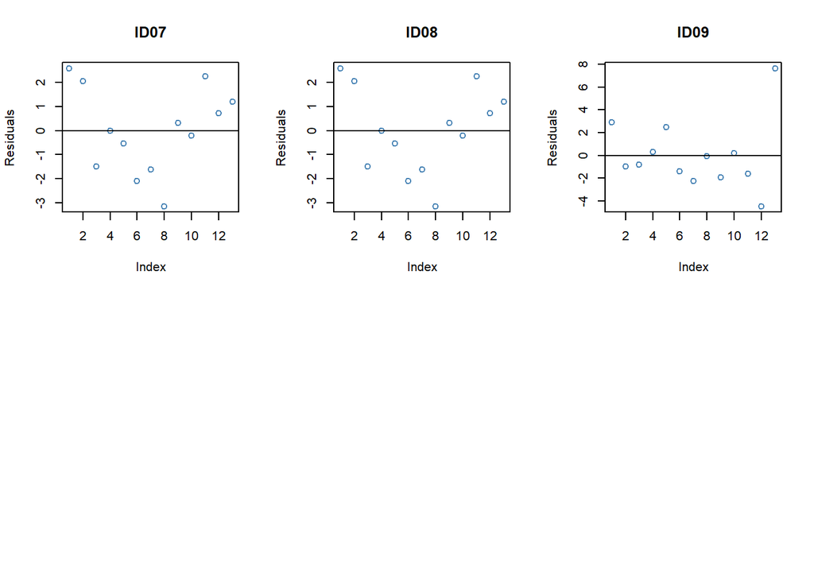

```r
par(mfrow = c(2, 3))

for (i in names(data)[-1][1:9]) {
  plot(resid(lm(get(i) ~ time, data)),
       ylab = "Residuals",
       main = i,
        col = "steelblue")
  abline(0, 0)
}
```

Now we do the same for Group B. First, the storages are created as previously done for Group A in lines 35 to 40.

```r
# Group B suffix = .B
 models.B   <- list() # storage for regression models
 slopes.B   <- c()    # stroage for the slopes
r.sqrds.B   <- c()    # storage for r squareds
```

Now the regressions are looped and the models, slopes and r quareds are extracted and stored.

```r
# Looping regressions of HR vs time for Group B
for (i in names(data)[-1][10:15]) { # [-1] = omits time, [10:15] = Group B
   models.B[[i]] <-         lm(get(i) ~ time, data)                 # store model
   slopes.B[[i]] <-    coef(lm(get(i) ~ time, data))["time"]        # store slope
  r.sqrds.B[[i]] <- summary(lm(get(i) ~ time, data))[["r.squared"]] # store r^2
}
```

Now the regressions are plotted

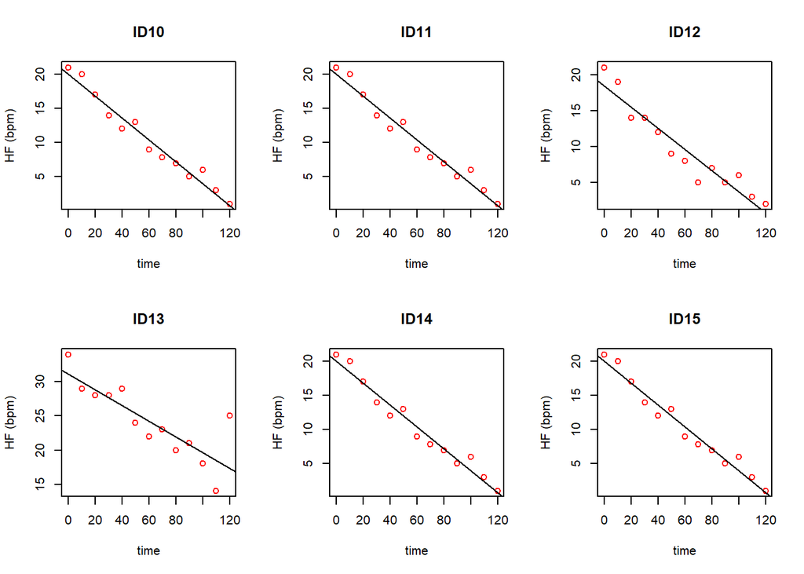

```r
# Looping regression plots for Group B
par(mfrow = c(2, 3)) # merges the looped graphs in one graph

for (i in names(data)[-1][10:15]) { # try indexing here as in other loops
  plot(get(i) ~ time,
         ylab = "HF (bpm)",
         main = i,
         col  = "red",
         data) # Plotting
  abline(models.B[[i]])  # add linear fit from models
}
```

Residual plots are created.

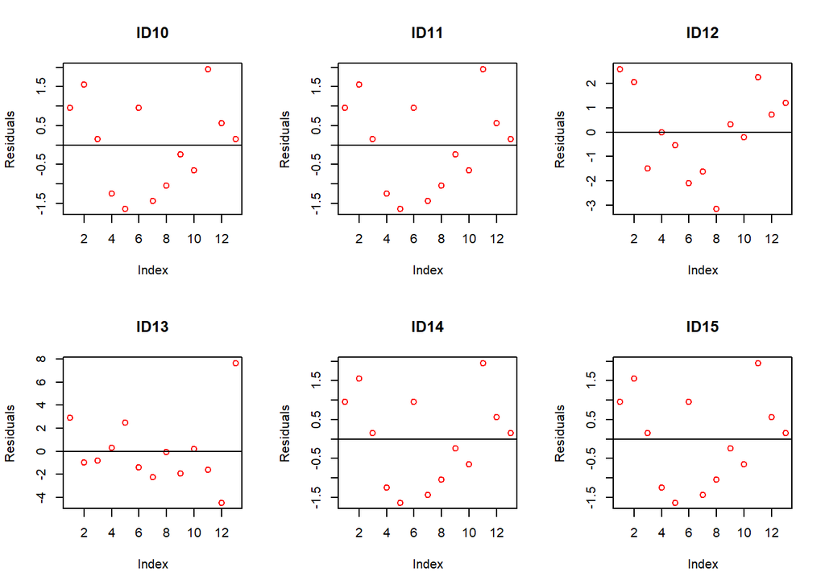

```r
par(mfrow = c(2, 3))

for (i in names(data)[-1][10:15]) {
  plot(resid(lm(get(i) ~ time, data)),
       ylab = "Residuals",
       main = i,
        col = "red")
  abline(0, 0)
}
```

Creating histograms for the r-squareds to show how frequent certain values occured.

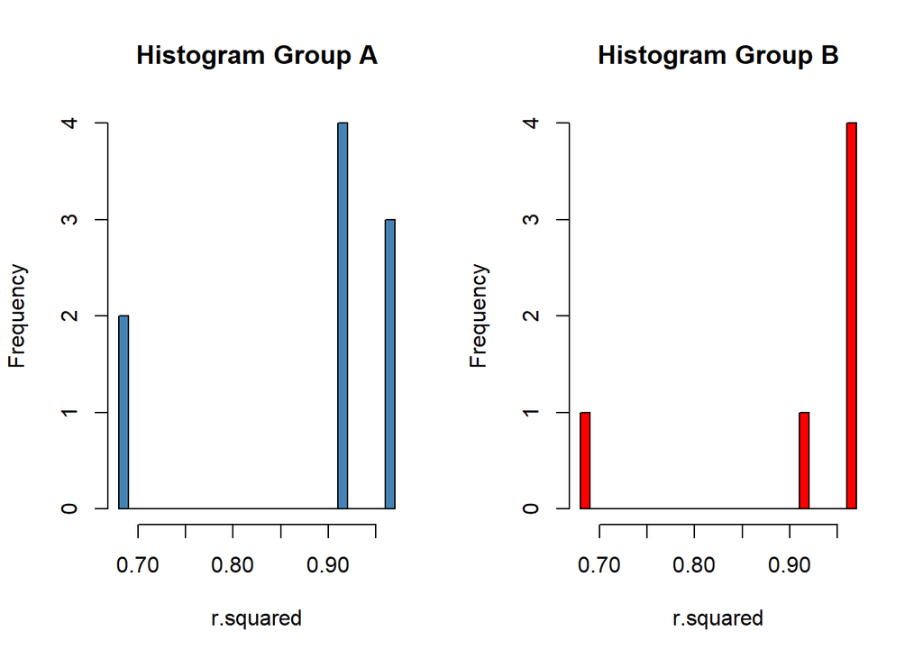

```r
# Histogram r squared's Group A
par(mfrow = c(1,2))

hist(
  r.sqrds.A,
  freq   = TRUE,
  col    = "steelblue",
  xlab   = "r.squared",
  breaks = 25,
  main   = "Histogram Group A"
)

# Histogram r squared's Group B
# par(mfrow = c(1,1))
hist(
  r.sqrds.B,
  freq   = TRUE,
  col    = "red",
  xlab   = "r.squared",
  breaks = 25,
  main   = "Histogram Group B"
)
```

## Conduct Statistical Tests

Assessing whether the slopes are Gaussian distributed.

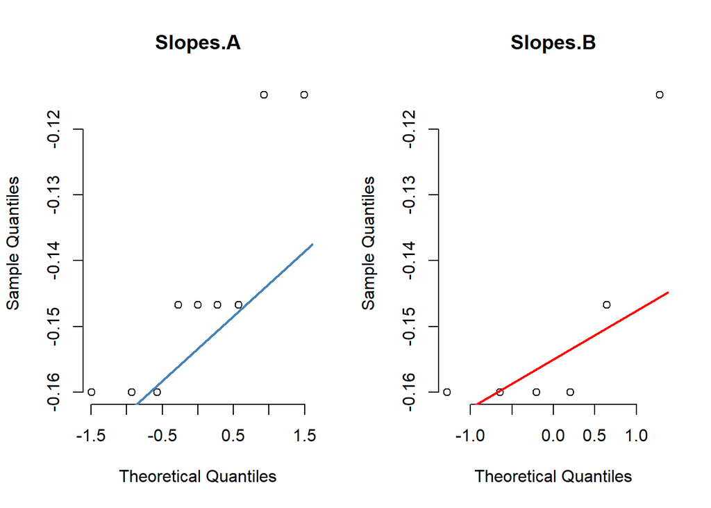

```r
# Assessing normal distribution Group A
par(mfrow = c(1,2)) # resets the "merge graphs" function

qqnorm(slopes.A,
       pch   = 1,
       frame = FALSE,
       main  = "Slopes.A")
qqline(slopes.A,
       col   = "steelblue",
       lwd   = 2)

# Assessing normal distribution Group B
# par(mfrow = c(1,1)) # resets the "merge graphs" function
qqnorm(slopes.B,
       pch   = 1,
       frame = FALSE,
       main  = "Slopes.B")
qqline(slopes.B,
       col   = "red",
       lwd   = 2)
```

```r
# Assessing if variances are the same
# F test for equal variances
var.test(slopes.A, slopes.B)
```

```
##
##  F test to compare two variances
##
## data:  slopes.A and slopes.B
## F = 0.94806, num df = 8, denom df = 5, p-value = 0.899
## alternative hypothesis: true ratio of variances is not equal to 1
## 95 percent confidence interval:
##  0.1403039 4.5670535
## sample estimates:
## ratio of variances
##          0.9480573
```

```r
# Conducting t-test
t.result <- t.test(
  slopes.A,
  slopes.B,
  paired      = FALSE,
  var.equal   = TRUE, # accroding to var.test result
  conf.level  = 0.95,
  alternative = "two.sided"
)

print(t.result)
```

```
##
##  Two Sample t-test
##
## data:  slopes.A and slopes.B
## t = 0.65905, df = 13, p-value = 0.5214
## alternative hypothesis: true difference in means is not equal to 0
## 95 percent confidence interval:
##  -0.01412974  0.02653511
## sample estimates:
##  mean of x  mean of y
## -0.1440537 -0.1502564
```

Plotting the results

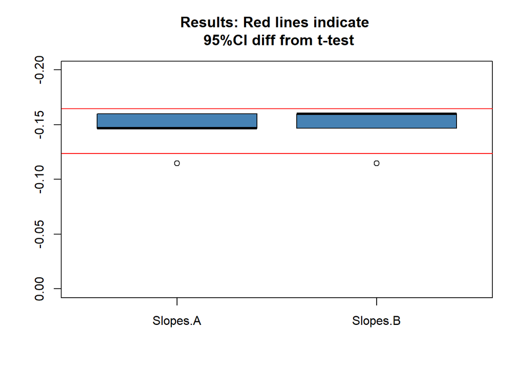

```r
boxplot(slopes.A,
        slopes.B,
        col = "steelblue",
       ylim = c(0.0,-0.2),
       main = "Results: Red lines indicate \n 95%CI diff from t-test",
       names = c("Slopes.A", "Slopes.B")
)
abline(h = mean(slopes.B) + t.result$conf.int[1], col = "red") # 95%CI low. lim
abline(h = mean(slopes.B) + t.result$conf.int[2], col = "red") # 95%CI upp. lim
```